# Why Do We Need an Initiator and Responder? Emotional Dynamics of Conflict Resolution

# 1 Introduction

Conflict resolution is a pivotal aspect of social interactions, with apologies playing a critical role in the reconciliation process. The willingness to apologize first and the expectation of an apology in return can significantly affect individuals’ emotional states. This study delves into these emotional responses, focusing on how initiator types — ‘always’, ‘conditional’, and ‘never’ — correlate with the anticipation of positive or negative feelings in conflict scenarios.

# 2 Methodology

We recruited 47 participants (*M<sub>age</sub>=33.55±19.74, N<sub>female</sub>=27*), who were asked to recall and describe an unresolved conflict and to imagine themselves in six hypothetical apology scenarios: (1)“You apologized first. They did not apologize afterwards” (Corresponding to the emotional variables below: You Apology Alone), (2) “You apologized first then they apologized”(You Received Return Apology), (3)“They apologized first. You did not apologize afterwards”(Other Apology Alone),(4)“They apologized first then you apologized”(Other Received Return Apology),(5)“Neither you nor they apologized”(Neither Apology) and (6)“You apologized first. They did not apologize afterwards but let you know they forgive you”(Forgiveness Without Apology). They then reported their expected emotional response on a scale from -30 (extremely negative) to 30 (extremely positive). The scenarios varied based on who initiated the apology and whether a return apology was received. We do it again and ask participants to indicate their preferences. Participants were also categorized into three initiator types based on their willingness to apologize first.

# 3 Results

## 3.1 Task 1 — Emotional Anticipation Analysis

### 3.1.1 Importance of Receiving a Return Apology for the First Apologizer

In the realm of interpersonal dynamics, the act of offering an apology often sets the stage for reconciliation and understanding. So, the author is very interested in the psychological and emotional significance that first apologizers place on receiving a reciprocal apology. We ask participants to recall an unsolved conflict and assume participants apologize first, their feelings about two scenarios:(1) others did not apologize, (2)others apologized. We found that receiving an apology will lead to more positive emotional perceptions, while not receiving an apology will lead to more negative emotional perceptions (*t<sub>46</sub>=-12.88, p<.001*). Because individuals strive for fairness in relationships, and even more consistency among their beliefs, values, and emotions. This indicates that if both parties apologize, then both parties are wrong in the conflict. If one party apologizes but the other party not apologizing, then only the apologizing party will be deemed to be wrong. When both parties apologize, it might be seen as a more equitable exchange (both parties sharing the “cost” of apologizing), and it restores a sense of balance and fairness, leading to positive emotions. If they did not receive a return apology, it could be perceived as an imbalance or unfairness, leading to negative feelings.

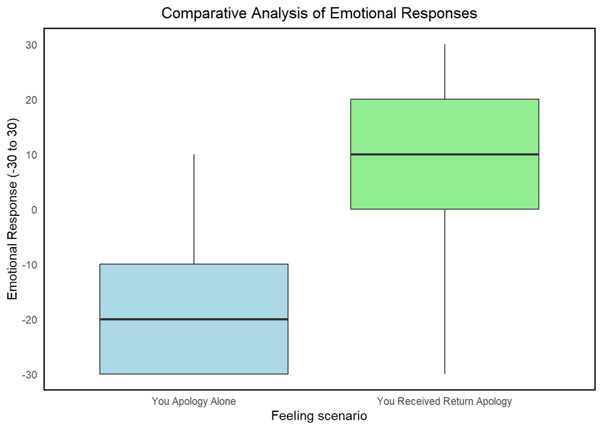

Figure 3.1: Contrast in Emotional Response to Apology Scenarios. When one apologizes first without receiving an apology(‘You Apology Alone’) versus when both parties apologize (‘You Received Return Apology’). The emotional responses range from extremely negative to extremely positive, highlighting the emotional impact of reciprocation in apologies.

### 3.1.2 Impact of Individual Differences on Emotional Variability

We also found there is a wide range of feelings in two scenarios. The spectrum of emotions elicited in scenarios involving apologies—or the absence thereof—highlights the significant influence of individual differences on emotional responses. Therefore, we focus on the individual differences in the “initiator type”. There are three types: ‘always’ initiators would be willing to apologize first, regardless of whether they’d expect a return apology; ‘conditional’ initiators would be willing to apologize first only if they’d expect a return apology; ‘never’ initiators would not be willing to apologize first, regardless of whether they’d expect a return apology.  
The analysis of variance (ANOVA) revealed two significant main effects. For the scenario, the type of scenario (You Apology Alone vs. You Received Return Apology) has a statistically significant effect on the emotional response for any type of initiator(*F<sub>(1,88)</sub>=102.71, p<.001*). This means that participants who apologized first and then received an apology had more significantly positive effects on their emotional response (M<sub>Received Return Apology</sub>=7.55±14.28) than no apology(M<sub>You Apology Alone</sub>=-18.57±11.89). There is also a significant main effect for initiator type, suggesting that participants’ emotional responses varied significantly according to their tendency to initiate apologies (always, conditional, never)(*F<sub>(2,88)</sub>=6.46, p=.002*), and ‘always’ initiators’ emotions response in all scenario (*M<sub>always</sub>=-0.36±17.47*)are more positive than ‘conditional’ (*M<sub>conditional</sub>=-9.81±19.79*)and ‘never’(*Mnever=-9.45±16.61*). No interaction effect is observed (*F<sub>(2,88)</sub>=0.36, p=.7*). This means that the combined effect of scenario and initiator type on emotional response is not statistically significant. In other words, the difference in emotional responses between scenarios does not depend on the initiator type.  
Subsequently, Tukey’s HSD post hoc analysis was conducted to compare emotional responses between the two scenarios: ‘You Apology Alone’ and ‘Received Return Apology’. The results indicated a statistically significant difference in emotional response when comparing the ‘You Apology Alone’ scenario to the ‘Received Return Apology’ scenario, with a mean difference of 26.13(*p < 0.001*). Specifically, the emotional response to ‘Received Return Apology’ was significantly higher (*mean difference = 26.13, 95% CI [20.75, 31.51]*) than to ’You Apology Alone’. This significant mean difference suggests that receiving an apology can have a substantial positive effect on emotional response, reinforcing the main effect observed in the ANOVA. Additionally, post hoc analysis using Tukey’s HSD test was conducted to further explore the differences between the initiator types. The test did not reveal any statistically significant differences between the groups: the emotional response for ‘always’ initiators did not significantly differ from ‘conditional’ initiators (*mean difference = -9.46, p = .73*) or ‘never’ initiators (*mean difference = -9.09, p = .16*), nor was there a significant difference between ‘conditional’ and ‘never’ initiators (*mean difference = .36, p = 1.00*). These results suggest that, although there is a main effect of initiator type on emotional response, the specific differences between each type of initiator are not statistically significant when considered pairwise.  
Apart from individual differences, one potential source of large variances in emotional feelings can be the context of the conflict. Due to the limitation of imagination-based experiments, when people imagine/recall conflicts, the context of conflicts may vary a lot. The variance in context, especially the intensity and the type of conflict, will have a fundamental effect on the emotional feelings. As well as whether the unresolved conflict occurred in the past or was imagined by the participants, may make this difference larger. And I will explain further in the discussion section.

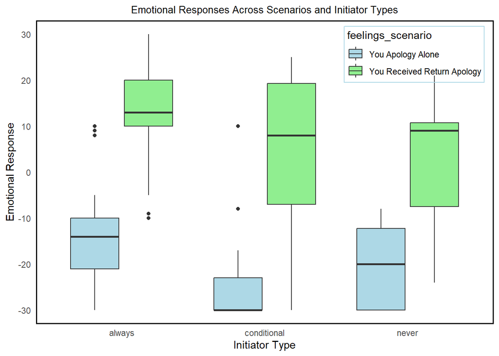

Figure 3.2: Emotional Responses Across Scenarios and Initiator Types.

### 3.1.3 Return Apology Is More Useful Than Forgiveness Without Apology.

The dynamics of interpersonal conflicts and resolutions are profoundly influenced by the actions taken by the involved parties, particularly in terms of apologies and forgiveness. We are particularly interested in whether an apology can be viewed as a form of forgiveness. We found that when participants apologized first, receiving a return apology made more significant positive feelings than forgiveness without apology(*t<sub>46</sub>=8.07, p<.001*).  
While an apology can serve as a direct acknowledgment of wrongdoing and a step towards reconciliation, forgiveness without an apology, although beneficial, might not provide the same closure or satisfaction to the aggrieved party. Mutual apologies promote relationship satisfaction. When one party apologizes and the other reciprocates, it restores a sense of fairness and equity, which is crucial for emotional satisfaction and relationship stability. Conversely, forgiveness without an apology, while noble, may leave unresolved feelings of inequity, as the emotional investment does not seem to be reciprocated.

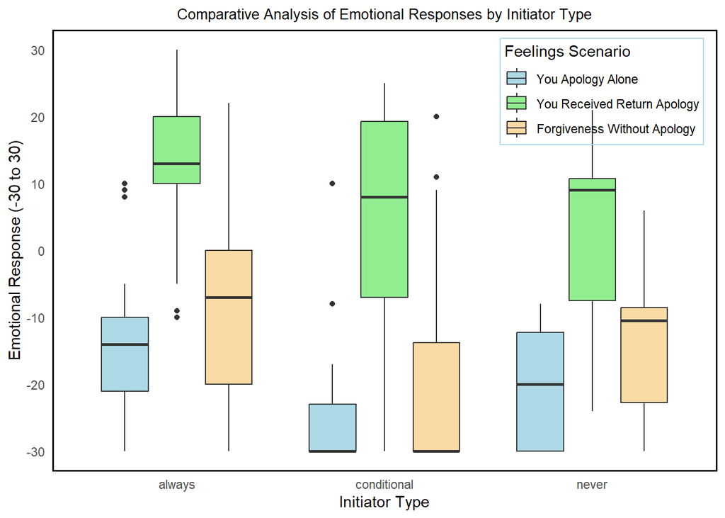

Figure 3.3: The variance in emotional responses among participants who apologize first across three scenarios: apology alone,received return apology, and forgiveness with no apology. The spread and median values indicate how each initiator type reacts emotionally to different apology outcomes.

## 3.2 Task 2 — Comparative and Proportional Analysis

The average feelings across the six scenarios, indicated the highest positivity when both parties apologized, with a steep drop in positive anticipation when apologies were not reciprocated.

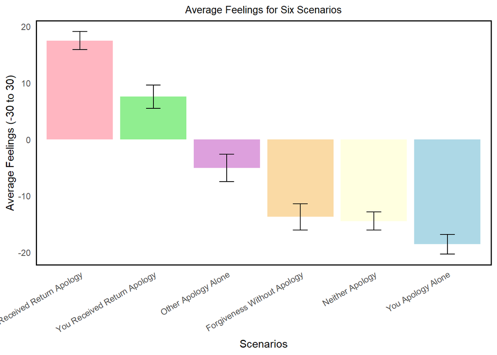

Figure 3.4: The average feelings across the six scenarios.

The ANOVA conducted across the six emotional response scenarios revealed a significant effect(*F<sub>(5,88)</sub>= 50.93, p<.001*), indicating variability in the emotional responses depending on the scenario. Post-hoc pairwise comparisons using the Bonferroni correction method were performed to identify specific differences between scenarios. These findings suggest that the average feelings across the six scenarios indicated the highest positivity when both parties apologized, with a steep drop in positive anticipation when apologies were not reciprocated.

Table 3.1: Pairwise T-Test Results with Bonferroni Correction

| Scenario_Comparison | T_Value | Degrees_of_Freedom | Original_P_Value | Adjusted_P_Value | Significance |
| --- | --- | --- | --- | --- | --- |
| Forgiveness Without Apology | -1.676 | 85.211 | 0.097 | 0.487 | FALSE |
| You Received Return Apology | -9.641 | 89.073 | 0.000 | 0.000 | TRUE |
| Other Apology Alone | -4.520 | 83.107 | 0.000 | 0.000 | TRUE |
| Other Received Return Apology | -15.175 | 91.619 | 0.000 | 0.000 | TRUE |
| Neither Apology | -1.742 | 91.382 | 0.085 | 0.424 | FALSE |

We let participants think again about the conflict, and imagine no one has yet apologized. We find that there is a significant difference in their preferences between the two options(*χ<sup>2</sup>=15.51, p<.001*) and 80% of participants prefer to choose to apologize first and then received the others’ return apology, while 20% chose neither apologize.When we think about the initiator type’s preferences, there is also a significant difference in different initiator type (*χ<sup>2</sup>=47, p<.001*). The result shows that ‘always’ and ‘conditional’ type participants prefer to choose apologize first, then receive return apologies. In contrast, the ‘never’ type prefers to choose neither party apologizes.

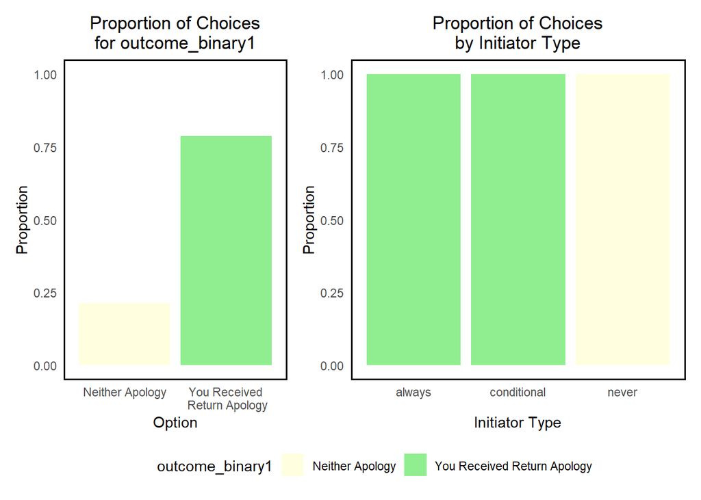

Figure 3.5: The choices are categorized into those who would apologize first and then receive an apology, and those who would not apologize at all. The proportions suggest significant behavioral trends among the always, conditional, and never initiators in the context of apology reciprocation.

Finally, we used VADER to analyze the sentiment from participants’ descriptions of conflict and found that mostly are negative(*M<sub>sentiment score</sub>=-0.23±0.41*). When using VADER (Valence Aware Dictionary and Sentiment Reasoner) in sentiment analysis, the value 0.05 is used as a common threshold to determine emotional tendencies and is used to distinguish positive, negative, or neutral emotions. In the context of our study, this seems counterintuitive: conflicts are mostly negative. Considering the differences in the training of different Natural Language Processing models, we also used the gpt-3.5-turbo model for analysis.

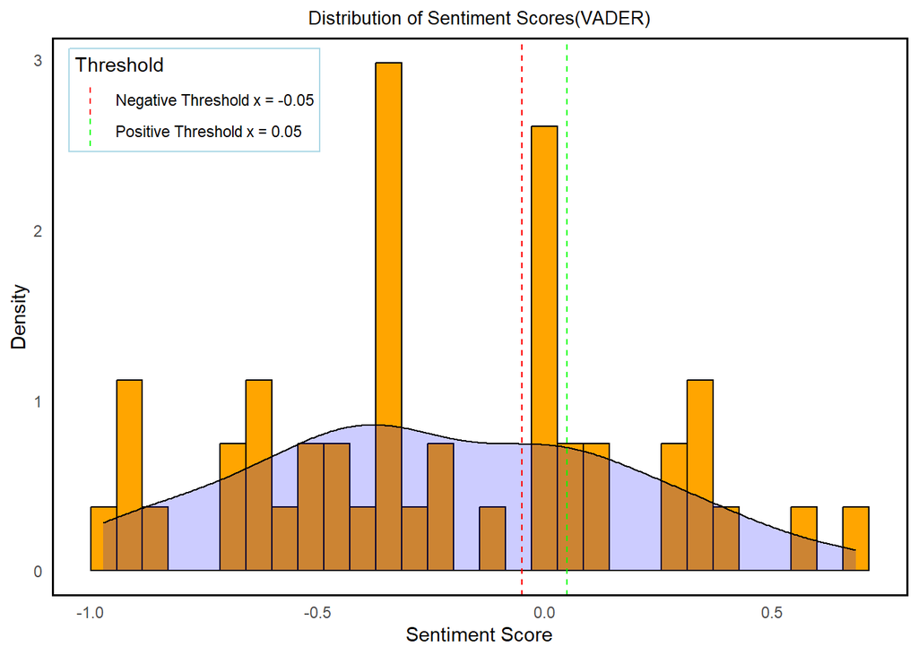

Figure 3.6: The frequency distribution of sentiment scores derived from participants’ descriptions of conflicts, showcasing the emotional tone of their narratives. Below -0.05 is negative sentiment, above 0.05 is positive sentiment, and between -0.05 and 0.05 is neutral sentiment.

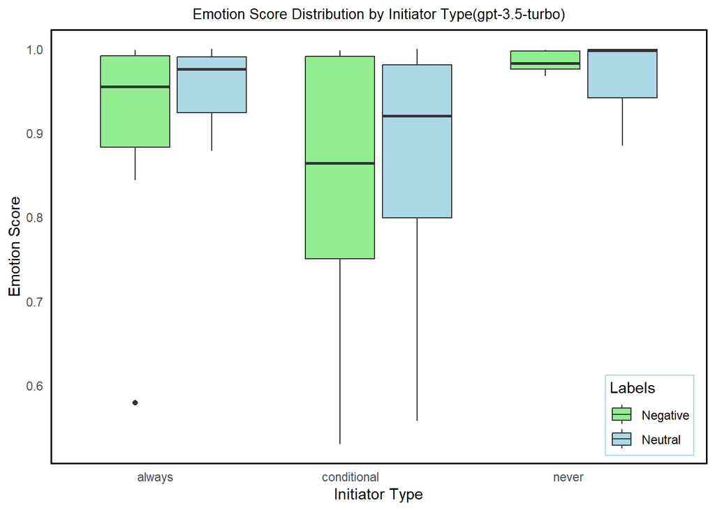

Table 3.2: Comparison of Emotion Scores Across Initiator Types.BC mean Bonferroni Corrected.

| Describe_Emotion | Initiator_type1 | Initiator_type2 | T_Value | Degrees_of_Freedom | Original_P_Value | Adjusted_P_Value | Significance |
| --- | --- | --- | --- | --- | --- | --- | --- |
| Negative | never | always | -2.175 | 13.660 | 0.048 | 0.286 | FALSE |
| Negative | never | conditional | -2.670 | 10.156 | 0.023 | 0.139 | FALSE |
| Negative | always | conditional | 1.287 | 15.851 | 0.217 | 1.000 | FALSE |
| Neutral | always | never | -0.148 | 2.897 | 0.892 | 1.000 | FALSE |
| Neutral | always | conditional | 1.240 | 4.374 | 0.277 | 1.000 | FALSE |
| Neutral | never | conditional | -1.219 | 5.422 | 0.273 | 1.000 | FALSE |

# 4 Discussion